# AE 12: Hypothesis Testing

Part 2

06.10.2021

## Resource for full examples in infer

https://infer.netlify.app/articles/observed_stat_examples.html

### From last class

```r
library(tidyverse)
library(infer)
```

```r
asheville <- read_csv("data/asheville.csv")
```

Suppose you are interested in whether the mean price per guest per night is actually less than $80. Conduct a hypothesis test to assess this claim.

**Hypotheses**

$H_0$: The mean price per guest per night is $80

$H_a$: The mean price per guest per night is less than $80

$H_0: \mu = 80$

$H_a: \mu < 80$

**Simulate null distribution**

```r
set.seed(1234)
```

```r
null_dist <- asheville %>%
  specify(response = ppg) %>%
  hypothesize(null = "point", mu = 80) %>%
  generate(reps = 1000, type = "bootstrap") %>%
  calculate(stat = "mean")
```

```r
mean_ppg <- asheville %>%
  summarise(mean_ppg = mean(ppg)) %>%
  pull()
```

**Visualize Null distribution using `ggplot`**

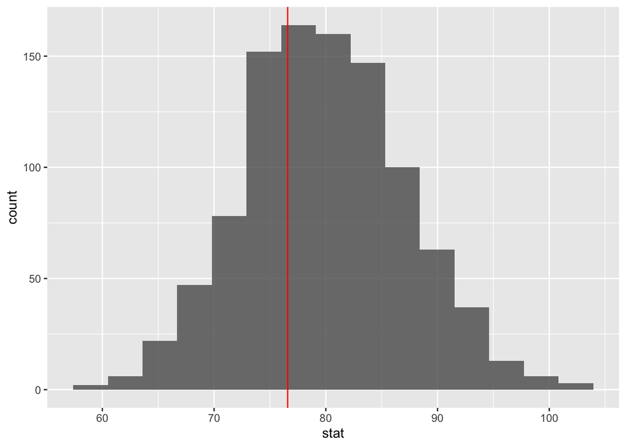

```r
ggplot(data = null_dist, aes(x = stat)) +
  geom_histogram(alpha = 0.8, bins = 15) +
  geom_vline(xintercept = mean_ppg, color = "red")
```

**Visualize null distribution using `infer`**

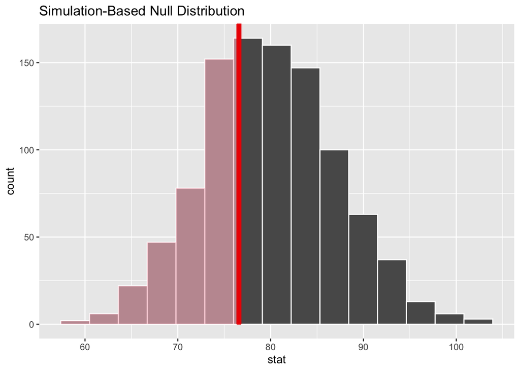

```r
visualize(null_dist) +
  shade_p_value(obs_stat = mean_ppg, direction = "less")
```

**Calculate p-value**

```r
p_val <- null_dist %>%
  filter(stat <= mean_ppg) %>%
  summarise(p_value = n() / nrow(null_dist)) %>%
  pull(p_value)
p_val
```

```
## [1] 0.336
```

**Conclusion**

The p-value of 0.336 is greater than $\alpha = 0.05$, so we fail to reject the null hypothesis. The data do not provide sufficient evidence that the mean price per night is less than $80.

## Clone a repo + start a new project

Clone the **ae-12** repo on [GitHub](https://github.com/sta199-summer2021) and start a new project in RStudio. Be sure to configure git in the RStudio console, so you can so you can push your results back up to GitHub.

```r
library(usethis)
use_git_config(user.name= "github username", user.email="your email")
```

### Exercise 1

Suppose you are interested in whether at least half of the Airbnb listings in Asheville are more than $50 per guest per night. What would be your null and alternative hypotheses?

#### Option 1

- $H_0$: The median price per guest per night is $50
- $H_a$: The median price per guest per night is greater than $50

#### Option 2

- $H_0$: The proportion of Airbnbs less than $50 ppg is 0.5
- $H_a$: The proportion of Airbnbs less than $50 ppg is less than 0.5

### Exercise 2

Simulate the null distribution to test your hypotheses. You can use 1000 reps for the in-class exercise.

#### Option 1

```r
set.seed(1234)
null_dist_opt1 <- asheville %>%
  specify(response = _____) %>%
  hypothesize(null = _____, ____ = _____) %>%
  generate(reps = _____, type = _____) %>%
  calculate(stat = ______ )
```

#### Option 2

```r
#create variable to track price
asheville <- asheville %>%
  mutate(less_50_ppg = if_else(ppg < 50, "Yes", "No"))
```

```r
set.seed(1234)
null_dist_opt2 <- asheville %>%
  specify(response = ______, ____ = ____) %>%
  hypothesize(null = _____, p = _____) %>%
  generate(reps = ______, type = _______) %>%
  calculate(stat = ______)
```

### Exercise 3

What was your p-value? What decision do you make with respect to your hypotheses, and what conclusion do you make in the context of the research problem?

#### Option 1

```r
#calculate observed statistic
obs_med <- asheville %>%
 # finish the code

obs_med
```

```r
null_dist_opt1 %>%
  filter( ______ ) %>%
  summarise(p_val = _______)
```

#### Option 2

```r
#calculate observed statistic
obs_prop <- asheville %>%
  # finish the code
```

```r
null_dist_opt2 %>%
  filter( ______ ) %>%
  summarise(p_val = _______)
```

### Exercise 4

Suppose you are interested in whether the proportion of listings with a price per guest per night greater than $50 is 0.5. How would your null and alternative hypotheses change in this case? Carry out the appropriate hypothesis test, and report your p-value, decision, and conclusion in context of the research problem.

$H_0$:

$H_a$:

```r
set.seed(1234)
```